# Data413HW2

Calissa Page

2024-02-25

# Problem 1

## Copy paste and run the tribble given below.

```r
library(tidyverse)
tribble( ~x,  ~y,  ~w,  ~z,
         210, 300, 220, 180,
         102, 100, 119, 187,
         176, 175, 188, 173,
         87,  95,  91,  94,
         202, 210, 234, 218,
         110, 122, 131, 128,
) -> dt
         dt
```

| x | y | w | z |
| --- | --- | --- | --- |
| 210 | 300 | 220 | 180 |
| 102 | 100 | 119 | 187 |
| 176 | 175 | 188 | 173 |
| 87 | 95 | 91 | 94 |
| 202 | 210 | 234 | 218 |
| 110 | 122 | 131 | 128 |

### 1a: Use and show a map function to find the “mean” of each column of the dt data table

```r
map(dt, mean)
```

```
## $x
## [1] 147.8333
##
## $y
## [1] 167
##
## $w
## [1] 163.8333
##
## $z
## [1] 163.3333
```

### 1b: Use and show a map function to find the “standard deviation” of each column of the dt data table

```r
map(dt, sd)
```

```
## $x
## [1] 54.45151
##
## $y
## [1] 79.12016
##
## $w
## [1] 58.40348
##
## $z
## [1] 44.66617
```

### 1c: Use and show a map function that will calculate the “square root” of each value of each column of the data table dt.

```r
map(dt, sqrt)
```

```
## $x
## [1] 14.491377 10.099505 13.266499  9.327379 14.212670 10.488088
##
## $y
## [1] 17.320508 10.000000 13.228757  9.746794 14.491377 11.045361
##
## $w
## [1] 14.832397 10.908712 13.711309  9.539392 15.297059 11.445523
##
## $z
## [1] 13.41641 13.67479 13.15295  9.69536 14.76482 11.31371
```

### 1d: Use R code to find the “mean”, “max”, “1st Quartile”, “3rd Quartile”, “Median”, and “Min” for each column of the dt data table. (Hint: You do not have to use a map function)

```r
summary(dt)
```

```
##        x               y               w               z
##  Min.   : 87.0   Min.   : 95.0   Min.   : 91.0   Min.   : 94.0
##  1st Qu.:104.0   1st Qu.:105.5   1st Qu.:122.0   1st Qu.:139.2
##  Median :143.0   Median :148.5   Median :159.5   Median :176.5
##  Mean   :147.8   Mean   :167.0   Mean   :163.8   Mean   :163.3
##  3rd Qu.:195.5   3rd Qu.:201.2   3rd Qu.:212.0   3rd Qu.:185.2
##  Max.   :210.0   Max.   :300.0   Max.   :234.0   Max.   :218.0
```

# Problem 2

## Write a function that uses a for loop that, for each iteration, randomly draws 5 observations from an exponential distribution with “rate” parameter 1 (use rexp()) and calculates its “mean”. It should do this 10,000 times. Choose an appropriate plot to plot the distribution of “means”.

```r
calmeans <- function() {
  means <- numeric(10000)

  for (i in 1:10000) {
    observations <- rexp(5, rate = 1)
    means[i] <- mean(observations)
  }

  return(means)
}
x <- calmeans()
```

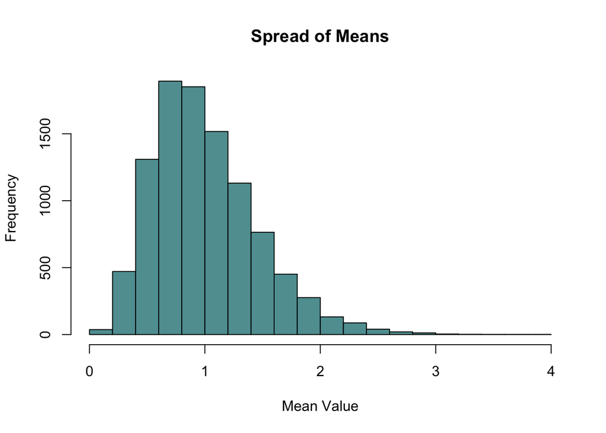

```r
hist(x, main = "Spread of Means", xlab = "Mean Value", col = "cadetblue", border = "black")
```

### 2a: Repeat part 1 by using a map_*() function

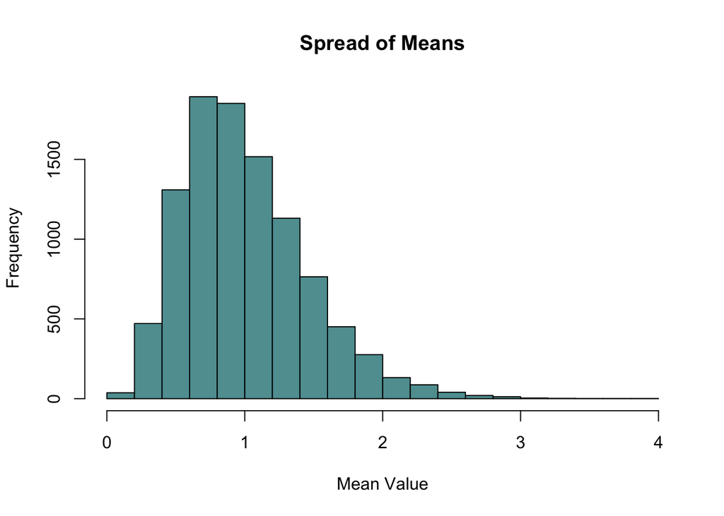

```r
x2 <- map_dbl(x, mean)

hist(x2, main = "Spread of Means", xlab = "Mean Value", col = "cadetblue", border = "black")
```

### 2b: Repeat part 1 by using the replicate() function

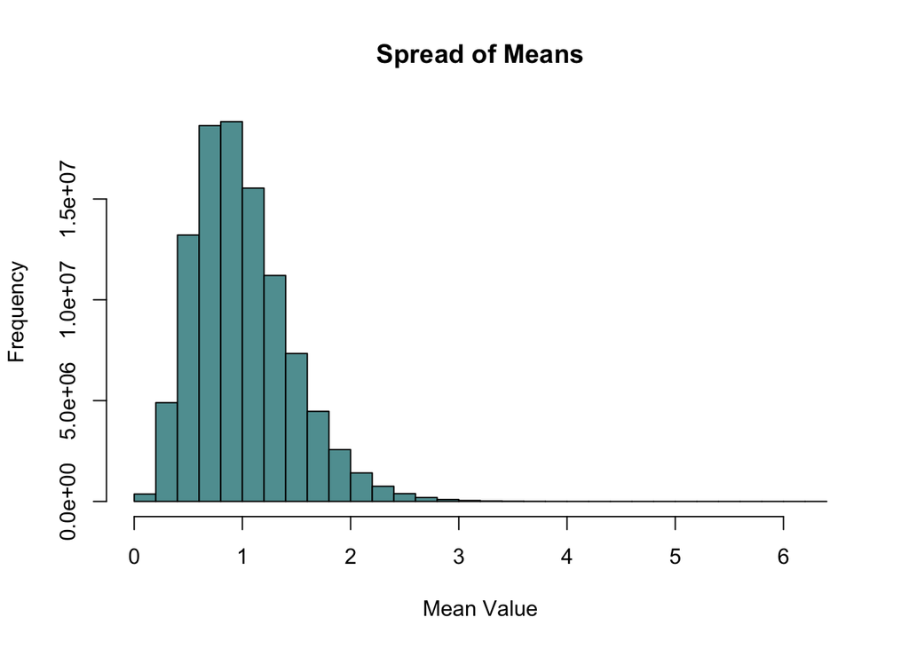

```r
x3 <- replicate(10000, calmeans())

hist(x3, main = "Spread of Means", xlab = "Mean Value", col = "cadetblue", border = "black")
```

### 2c: Use another for loop that will print out plots for sample sizes of 5, 10, and 20 observations (instead of just 5)

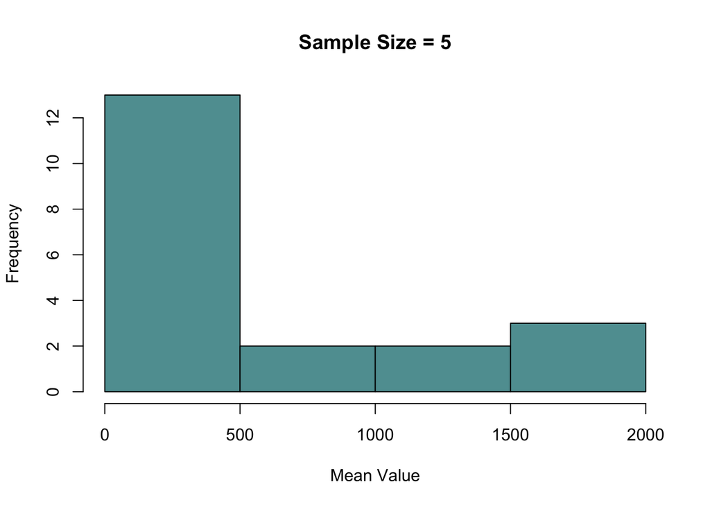

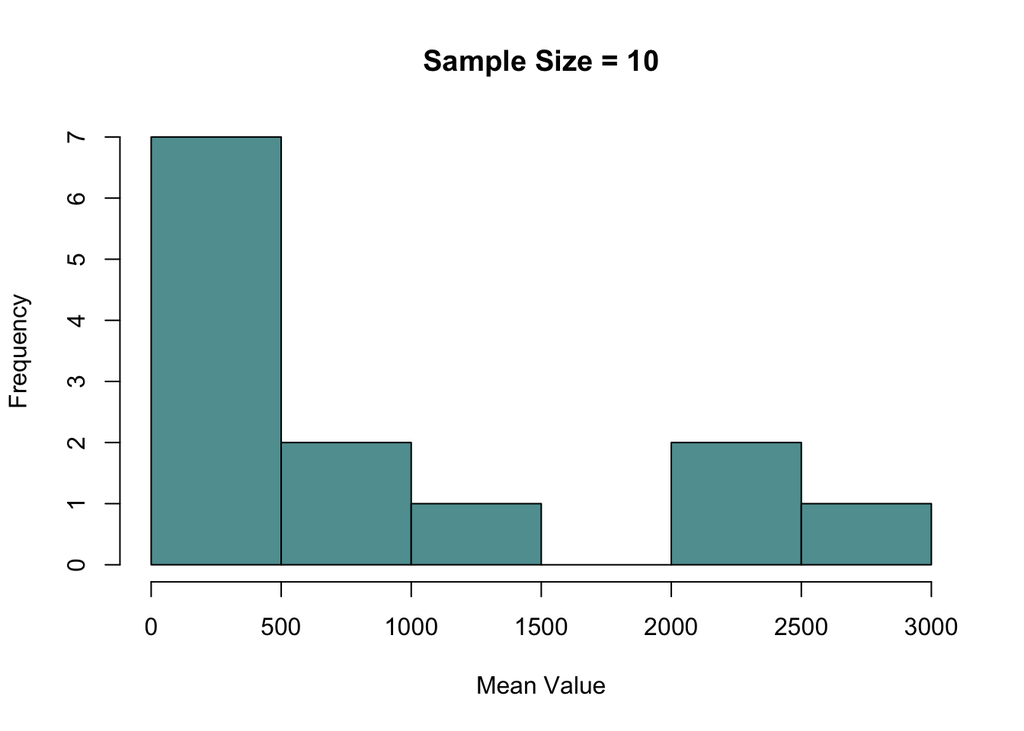

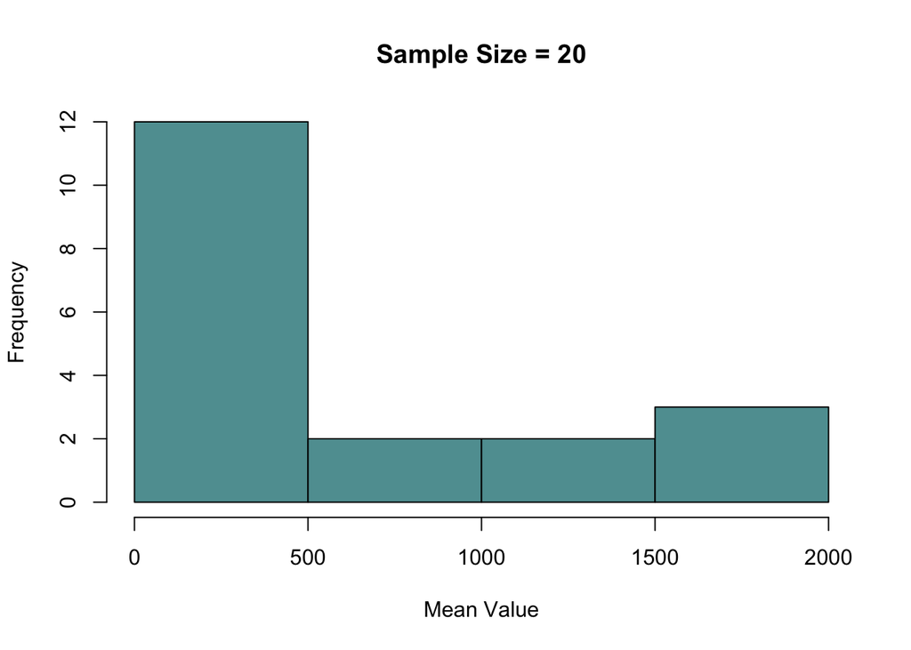

```r
calmeans_modified <- function(sample_sizes) {
  plots <- list()

  for (size in sample_sizes) {
    means <- numeric(10000)

    for (i in 1:10000) {
      observations <- rexp(size, rate = 1)
      means[i] <- mean(observations)
    }

    plots[[paste("Sample Size =", size)]] <- hist(means, main = paste("Spread of Means (Sample Size =", size, ")"),
                                                 xlab = "Mean Value", col = "cadetblue", border = "black", plot = FALSE)
  }

  return(plots)
}

sample_sizes <- c(5, 10, 20)
plots_list <- calmeans_modified(sample_sizes)
for (i in seq_along(plots_list)) {
  values <- plots_list[[i]]$counts # Extract numeric values from the histogram object
  hist(values, main = names(plots_list)[i], xlab = "Mean Value", col = "cadetblue", border = "black")
}
```

# Problem 3

## Use and show R coding to calculate the “standard deviation” for each variable of the data table mtcars using the “Special For Loop Method”

```r
output <- vector("double", length = ncol(mtcars))

for (i in seq_along(mtcars)) {
  output[[i]] <- sd(mtcars[[i]])
}

# Print the standard deviation for each variable
output
```

```
##  [1]   6.0269481   1.7859216 123.9386938  68.5628685   0.5346787   0.9784574
##  [7]   1.7869432   0.5040161   0.4989909   0.7378041   1.6152000
```